# HW2

Anthony Cunningham

January 29, 2019

# Part 3

Adding the “origin=0” command will fix this issue as it will stretch the range of the axis showing “onAssistance” to zero, as shown:

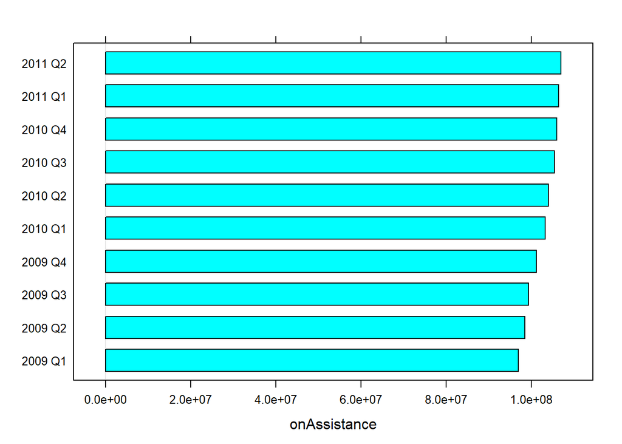

```r
library(lattice)
(welfareBar <- barchart(quarter ~ onAssistance, data=welfare, origin=0))
```

This bar chart with the range of values stretching down to zero is more appropriate, as observervations made about the ratio of different bar values can now be appropriately put into perspective. While there is a clear upward trend, it is not nearly as pronounced as with the graphic from the USA Today article.

# Part 4

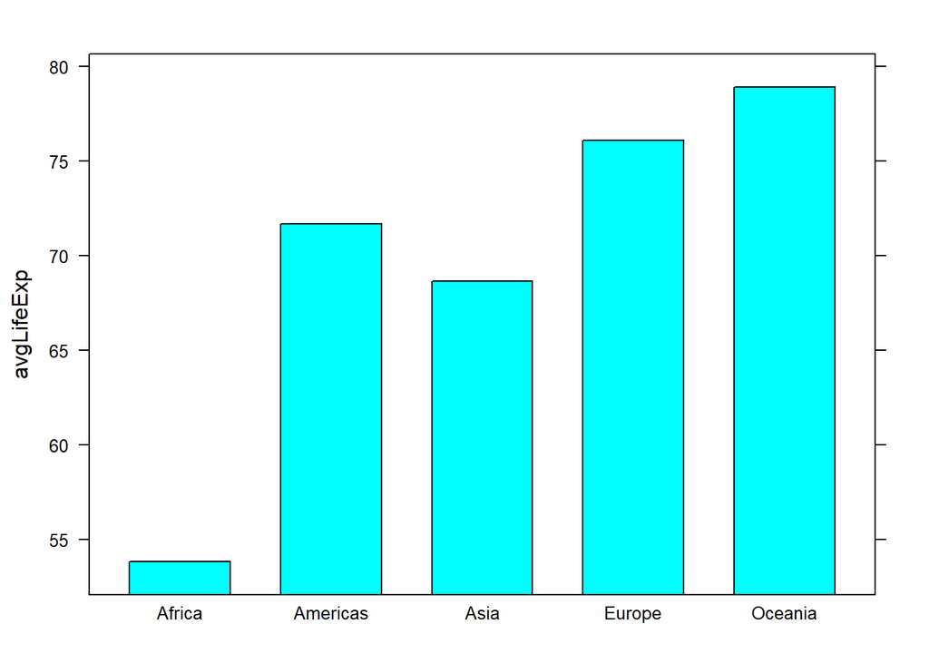

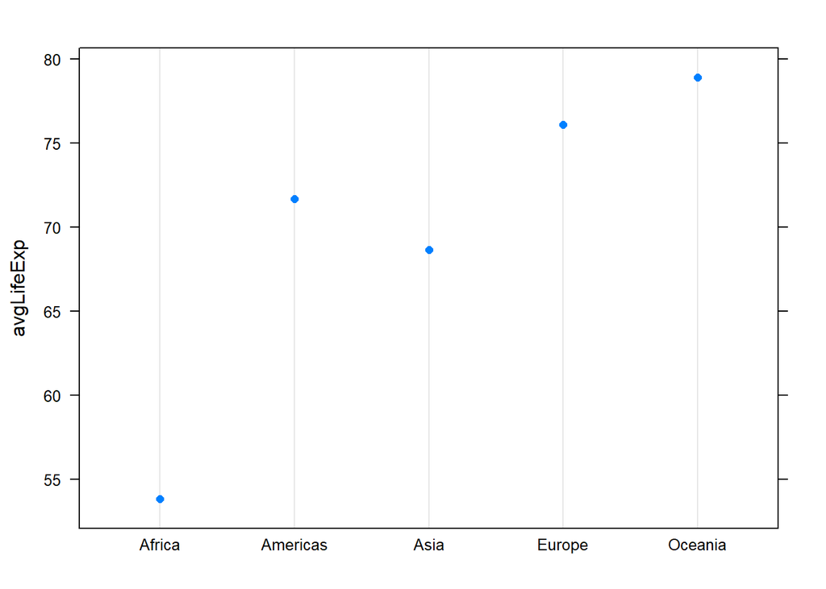

I prefer the Dot Plot since they are easier on the eyes when graphing group summaries while conveying the same information that a Bar Chart does. Also, Bar Charts suffer from the “Zero-Baseline” issue mentioned in Part 3, as viewers are inherently drawn to the length of bars in comparison to others, while this is not the case in Dot Plots. Additionally, it would make more sense to evaluate numerical differences between continents, rather than the ratio, in the variable of interest, average life expectancy. Dot Plots suit these analyses better. If we were to exclude Africa and Oceania, I would be even more compelled to use a Dot Plot, as the differences in average life expectancy are not very big (only an 8 year spread among the three included continents), so using a Bar Chart would mislead the viewer into observing larger differences, even if they are not meaningful.